# Boots For Days!

Carly S McDermott

2025-04-01

[figure not shown]

## Part 1

Using the “KamilarAndCooperData.csv” dataset, run a linear regression looking at log(HomeRange_km2) in relation to log(Body_mass_female_mean) and report your 𝛽 coefficients (slope and intercept).

```r
#start by loading my packages and data
library(curl) #curl is used to transfer my data
f <- curl("https://raw.githubusercontent.com/fuzzyatelin/fuzzyatelin.github.io/master/AN588_Fall21/KamilarAndCooperData.csv")
data <- read.csv(f, header = TRUE, sep = ",", stringsAsFactors = FALSE)
head(data) #overall data looks good
```

```
##               Scientific_Name          Family          Genus      Species
## 1 Allenopithecus_nigroviridis Cercopithecidae Allenopithecus nigroviridis
## 2         Allocebus_trichotis Cercopithecidae      Allocebus    trichotis
## 3           Alouatta_belzebul        Atelidae       Alouatta     belzebul
## 4             Alouatta_caraya        Atelidae       Alouatta       caraya
## 5            Alouatta_guariba        Atelidae       Alouatta      guariba
## 6           Alouatta_palliata        Atelidae       Alouatta     palliata
##   Brain_Size_Species_Mean Brain_Size_Female_Mean   Brain_size_Ref
## 1                   58.02                  53.70 Isler et al 2008
## 2                      NA                     NA
## 3                   52.84                  51.19 Isler et al 2008
## 4                   52.63                  47.80 Isler et al 2008
## 5                   51.70                  49.08 Isler et al 2008
## 6                   49.88                  48.04 Isler et al 2008
##   Body_mass_male_mean Body_mass_female_mean Mass_Dimorphism
```

[output cut: 62 more lines]

```r
# running linear regression:
reg1 <-lm(data=data, log(data$HomeRange_km2)~log(data$Body_mass_female_mean))
summary(reg1)
```

```
##
## Call:
## lm(formula = log(data$HomeRange_km2) ~ log(data$Body_mass_female_mean),
##     data = data)
##
## Residuals:
##     Min      1Q  Median      3Q     Max
## -3.3929 -0.9433 -0.0126  1.0944  3.6826
##
## Coefficients:
##                                 Estimate Std. Error t value Pr(>|t|)
## (Intercept)                     -9.44123    0.67293  -14.03   <2e-16 ***
## log(data$Body_mass_female_mean)  1.03643    0.08488   12.21   <2e-16 ***
## ---
## Signif. codes:  0 '***' 0.001 '**' 0.01 '*' 0.05 '.' 0.1 ' ' 1
##
## Residual standard error: 1.423 on 135 degrees of freedom
##   (76 observations deleted due to missingness)
## Multiple R-squared:  0.5248, Adjusted R-squared:  0.5213
## F-statistic: 149.1 on 1 and 135 DF,  p-value: < 2.2e-16
```

- We learn from the summary of reg1 above that the model produces an beta intercept of -9.44123 and the slope is 1.03643.

## Part 2

Then, use bootstrapping to sample from your data 1000 times with replacement, each time fitting the same model and calculating the same coefficients. This generates a sampling distribution for each 𝛽 coefficient.

```r
library(boot) # bootstrapping package

# creating a function to return slope and beta value coefficients
boots <- function(formula, data, indices) {
  datar <- data[indices, ]
  fit <- lm(formula, data = datar)
  return(coef(fit))
}
set.seed(1234)

#this represents 1000 replications
boots1 <- boot(data = data, statistic = boots, R = 1000, formula = log(HomeRange_km2) ~ log(Body_mass_female_mean))
print(boots1)
```

```
##
## ORDINARY NONPARAMETRIC BOOTSTRAP
##
##
## Call:
## boot(data = data, statistic = boots, R = 1000, formula = log(HomeRange_km2) ~
##     log(Body_mass_female_mean))
##
##
## Bootstrap Statistics :
##      original        bias    std. error
## t1* -9.441231  0.0042381538  0.57283663
## t2*  1.036432 -0.0009153567  0.07308898
```

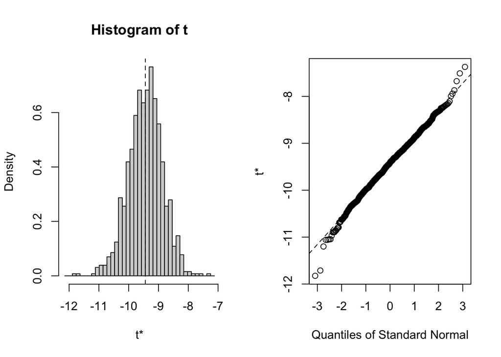

```r
# shows the distribution of the coefficients (intercept & slope)
plot(boots1, index = 1)  #intercept
```

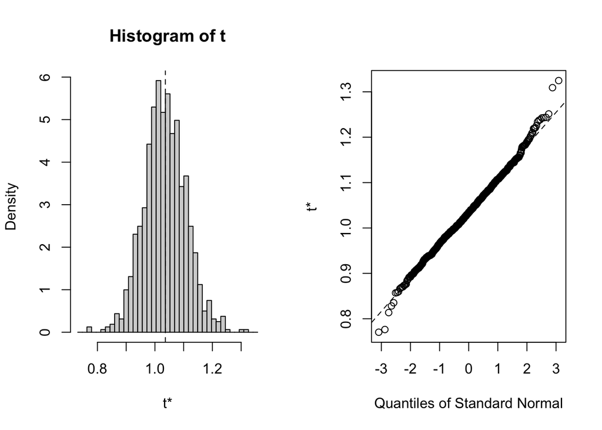

```r
plot(boots1, index = 2)  #slope
```

- Estimate the standard error for each of your 𝛽 coefficients as the standard deviation of the sampling distribution from your bootstrap and determine the 95% CI for each of your 𝛽 coefficients based on the appropriate quantiles from your sampling distribution.

```r
# (according to R In Action) bca is preferable here because it provides an interval that makes simple adjustments for bias
boot.ci(boots1, type = "bca", index = 1)  # 95% CI for intercept
```

```
## BOOTSTRAP CONFIDENCE INTERVAL CALCULATIONS
## Based on 1000 bootstrap replicates
##
## CALL :
## boot.ci(boot.out = boots1, type = "bca", index = 1)
##
## Intervals :
## Level       BCa
## 95%   (-10.680,  -8.365 )
## Calculations and Intervals on Original Scale
```

```r
boot.ci(boots1, type = "bca", index = 2)  # 95% CI for slope
```

```
## BOOTSTRAP CONFIDENCE INTERVAL CALCULATIONS
## Based on 1000 bootstrap replicates
##
## CALL :
## boot.ci(boot.out = boots1, type = "bca", index = 2)
##
## Intervals :
## Level       BCa
## 95%   ( 0.904,  1.195 )
## Calculations and Intervals on Original Scale
```

^ i really like this function/command and makes visualizing these confidence intervals very clear and straightforward!

- How does the former compare to the SE estimated from your entire dataset using the formula for standard error implemented in lm()?

**Differences In Analysis of SE:**

- In the original: standard error is estimated from the original model (reg1) which is just is based on the assumptions of linear regression (including normality + homoscedasticity)
- In bootstrapped model: standard error is standard deviation of the bootstrapped coefficient estimates across the 1000 datasets we sampled 1000

```r
summary(reg1)$coefficients[,2]  # se from lm() model (part 1) (,2 because this only pulls out se-which is column 2)
```

```
##                     (Intercept) log(data$Body_mass_female_mean)
##                      0.67293459                      0.08487709
```

```r
# standard errors from bootstrapping (part 2)
sd(boots1$t[,1])  # se of intercept
```

```
## [1] 0.5728366
```

```r
sd(boots1$t[,2])  # se of slope
```

```
## [1] 0.07308898
```

We can see here that the se for the beta intercept and slope would be similar (original model is slightly higher)

REG1 (estimate):

- 𝛽 coefficient: 0.67293459
- slope: 0.08487709

BOOTS:

- 𝛽 coefficient: 0.5728366
- slope: 0.07308898

**Comparison**: Basically these values are very similar. This makes sense as if the original dataset follows the assumptions of linear regression, the standard error from both methods should be relatively similar. Say our data was not normal (i.e. not normal residual) the bootstrap standard error might deviate from the estimate of the first model.

- How does the latter compare to the 95% CI estimated from your entire dataset?

```r
#creating confidence interval for entire model
confint(reg1) #level is already set to .95
```

```
##                                       2.5 %    97.5 %
## (Intercept)                     -10.7720889 -8.110374
## log(data$Body_mass_female_mean)   0.8685707  1.204292
```

REG1 (estimate):

- 95% CI Interval for 𝛽: **(-10.7720889, -8.110374)**
- 95% CI Interval for slope: **(0.8685707 1.204292)**

BOOTS:

- 95% CI Interval for 𝛽: **(-10.680, -8.365)**
- 95% CI Interval for slope: **(0.904, 1.195)**

**Comparison**: The 95% CIs from both methods are pretty close, supporting that the data likely meet the assumptions of linear regression. we see slope interval of 95% CIs for the bootstrapping is slightly narrower.

## Challenges That I Faced:

- Bootstrapping in general. I still don’t feel the most comfortable with it but like anything regarding coding that I’ve learned this semester, it will likely take more practice!
- I pretty much relied on the textbook R in Action for a defined summary/walk through of how to perform this function, which I found to be helpful when before I was very confused.
- Overall, I felt good about the actual creation of the model! Interpreting data can sometimes be a struggle for me because I find statistics to be tricky but this seemed pretty straightforward!
- Again, trying to interpret the SE of the mean and why the calculations are different for the estimate vs the actual 1000 samples was an adjustment, just because on the different components of the data that I was working with.